# Оптимизация маркетинговых затрат для Яндекс.Афиши

## Описание данных

Таблица visits (лог сервера с информацией о посещениях сайта):

- Uid — уникальный идентификатор пользователя
- Device — категория устройства пользователя
- Start Ts — дата и время начала сессии
- End Ts — дата и время окончания сессии
- Source Id — идентификатор рекламного источника, из которого пришел пользователь

Таблица orders (информация о заказах):

- Uid — уникальный id пользователя, который сделал заказ
- Buy Ts — дата и время заказа
- Revenue — выручка Яндекс.Афиши с этого заказа

Таблица costs (информация о затратах на маркетинг):

- source_id — идентификатор рекламного источника
- dt — дата
- costs — затраты на этот рекламный источник в этот день

```python
import pandas as pd
import numpy as np

from scipy import stats as st

import datetime
import decimal

import seaborn as sns
import matplotlib.pyplot as plt
from IPython.display import display
%matplotlib inline

sns.set(style='white')

from pylab import rcParams
rcParams['figure.figsize'] = 15, 10

import warnings
warnings.simplefilter('ignore')
```

```python
visits = pd.read_csv('')
orders = pd.read_csv('')
costs = pd.read_csv('')
```

# Подготовка данных

### Визиты

```python
visits.info()
visits.head()
```

```
<class 'pandas.core.frame.DataFrame'>
RangeIndex: 359400 entries, 0 to 359399
Data columns (total 5 columns):
 #   Column     Non-Null Count   Dtype
---  ------     --------------   -----
 0   Device     359400 non-null  object
 1   End Ts     359400 non-null  object
 2   Source Id  359400 non-null  int64
 3   Start Ts   359400 non-null  object
 4   Uid        359400 non-null  uint64
dtypes: int64(1), object(3), uint64(1)
memory usage: 13.7+ MB
```

|  | Device | End Ts | Source Id | Start Ts | Uid |
| --- | --- | --- | --- | --- | --- |
| 0 | touch | 2017-12-20 17:38:00 | 4 | 2017-12-20 17:20:00 | 16879256277535980062 |
| 1 | desktop | 2018-02-19 17:21:00 | 2 | 2018-02-19 16:53:00 | 104060357244891740 |
| 2 | touch | 2017-07-01 01:54:00 | 5 | 2017-07-01 01:54:00 | 7459035603376831527 |
| 3 | desktop | 2018-05-20 11:23:00 | 9 | 2018-05-20 10:59:00 | 16174680259334210214 |
| 4 | desktop | 2017-12-27 14:06:00 | 3 | 2017-12-27 14:06:00 | 9969694820036681168 |

```python
visits.describe()
```

|  | Source Id | Uid |
| --- | --- | --- |
| count | 359400.000000 | 3.594000e+05 |
| mean | 3.750515 | 9.202557e+18 |
| std | 1.917116 | 5.298433e+18 |
| min | 1.000000 | 1.186350e+13 |
| 25% | 3.000000 | 4.613407e+18 |
| 50% | 4.000000 | 9.227413e+18 |
| 75% | 5.000000 | 1.372824e+19 |
| max | 10.000000 | 1.844668e+19 |

### Выводы

- Пропусков нет
- Приведем названия столбцов к нижему регистру
- Столбцы Start Ts и End Ts имеют тип object, изменим формат данных на datetime

```python
visits.columns = visits.columns.str.lower()
visits['start ts'] = pd.to_datetime(visits['start ts'])
visits['end ts'] = pd.to_datetime(visits['end ts'])
```

### Заказы

```python
orders.info()
orders.head()
```

```
<class 'pandas.core.frame.DataFrame'>
RangeIndex: 50415 entries, 0 to 50414
Data columns (total 3 columns):
 #   Column   Non-Null Count  Dtype
---  ------   --------------  -----
 0   Buy Ts   50415 non-null  object
 1   Revenue  50415 non-null  float64
 2   Uid      50415 non-null  uint64
dtypes: float64(1), object(1), uint64(1)
memory usage: 1.2+ MB
```

|  | Buy Ts | Revenue | Uid |
| --- | --- | --- | --- |
| 0 | 2017-06-01 00:10:00 | 17.00 | 10329302124590727494 |
| 1 | 2017-06-01 00:25:00 | 0.55 | 11627257723692907447 |
| 2 | 2017-06-01 00:27:00 | 0.37 | 17903680561304213844 |
| 3 | 2017-06-01 00:29:00 | 0.55 | 16109239769442553005 |
| 4 | 2017-06-01 07:58:00 | 0.37 | 14200605875248379450 |

```python
orders.describe()
```

|  | Revenue | Uid |
| --- | --- | --- |
| count | 50415.000000 | 5.041500e+04 |
| mean | 4.999647 | 9.098161e+18 |
| std | 21.818359 | 5.285742e+18 |
| min | 0.000000 | 3.135781e+14 |
| 25% | 1.220000 | 4.533567e+18 |
| 50% | 2.500000 | 9.102274e+18 |
| 75% | 4.890000 | 1.368290e+19 |
| max | 2633.280000 | 1.844617e+19 |

Минимальное значение в revenue — нулевое, поэтому, проверю количество нулевых значений в столбце

```python
orders_null = orders.query('Revenue == "0"').count()
orders_null
```

```
Buy Ts     51
Revenue    51
Uid        51
dtype: int64
```

51 нулевое значение в столбце revenue.

### Выводы

- Минимальное значение в колонке Revenue — нулевое
- Приведем названия столбцов к нижему регистру
- Изменим формат данных в столбце Buy Ts на datetime
- Создадим столбец month_of_purchase, оставив в нем только месяц, это потребуется для когортного анализа
- 51 нулевое значение в столбце revenue

Не указаны единицы измерения в столбце Revenue, предположим, что значения в долларах.

```python
orders.columns = orders.columns.str.lower()
orders['buy ts'] = pd.to_datetime(orders['buy ts'])
orders['month_of_purchase'] = orders['buy ts'].astype('datetime64[M]')
```

### Расходы

```python
costs.info()
costs.head()
```

```
<class 'pandas.core.frame.DataFrame'>
RangeIndex: 2542 entries, 0 to 2541
Data columns (total 3 columns):
 #   Column     Non-Null Count  Dtype
---  ------     --------------  -----
 0   source_id  2542 non-null   int64
 1   dt         2542 non-null   object
 2   costs      2542 non-null   float64
dtypes: float64(1), int64(1), object(1)
memory usage: 59.7+ KB
```

|  | source_id | dt | costs |
| --- | --- | --- | --- |
| 0 | 1 | 2017-06-01 | 75.20 |
| 1 | 1 | 2017-06-02 | 62.25 |
| 2 | 1 | 2017-06-03 | 36.53 |
| 3 | 1 | 2017-06-04 | 55.00 |
| 4 | 1 | 2017-06-05 | 57.08 |

```python
costs.describe()
```

|  | source_id | costs |
| --- | --- | --- |
| count | 2542.000000 | 2542.000000 |
| mean | 4.857199 | 129.477427 |
| std | 3.181581 | 156.296628 |
| min | 1.000000 | 0.540000 |
| 25% | 2.000000 | 21.945000 |
| 50% | 4.000000 | 77.295000 |
| 75% | 9.000000 | 170.065000 |
| max | 10.000000 | 1788.280000 |

### Выводы

- Нулевых значений нет
- Столбец dt имеет тип object, хотя там дата и время. Изменим формат данных на datetime
- Добавлю столбец month с месяцем, выделив его из dt

Не указаны единицы измерения в столбце costs, предположим, что значения в долларах

```python
costs['dt'] = pd.to_datetime(costs['dt'], format='%Y-%m-%d')

costs['month'] = costs['dt'].astype('datetime64[M]')
```

# Анализ по продукту

## Вычислим DAU, WAU, MAU

Чтобы посчитать недельное и месячное использование, выделим в отдельные столбцы год, месяц и неделю, а также полную дату.

```python
visits['session_year'] = visits['start ts'].dt.year
visits['session_month'] = visits['start ts'].dt.month
visits['session_week'] = visits['start ts'].dt.week
visits['session_date'] = visits['start ts'].dt.date
```

Сгруппируем данные по уникальным пользователям и вычислим среднее:

```python
dau_total = visits.groupby('session_date').agg({'uid': 'nunique'}).mean()
wau_total = visits.groupby(['session_year', 'session_week']).agg({'uid': 'nunique'}).mean()
mau_total = visits.groupby(['session_year', 'session_month']).agg({'uid': 'nunique'}).mean()


print('В день сервисом в среднем пользуются {} человек'.format(int(dau_total)))
print('В неделю сервисом в среднем пользуются {} человек'.format(int(wau_total)))
print('В месяц сервисом в среднем пользуются {} человек'.format(int(mau_total)))
```

```
В день сервисом в среднем пользуются 907 человек
В неделю сервисом в среднем пользуются 5716 человек
В месяц сервисом в среднем пользуются 23228 человек
```

```python
sticky_wau = dau_total / wau_total
sticky_mau = dau_total / mau_total
print('Недельная вовлеченность аудитории: {:.2%}'.format(sticky_wau[0]))
print('Месячная вовлеченность аудитории: {:.2%}'.format(sticky_mau[0]))
```

```
Недельная вовлеченность аудитории: 15.88%
Месячная вовлеченность аудитории: 3.91%
```

### Выводы

- DAU = 907
- WAU = 5716
- MAU = 23228

Вовлеченность аудитории невысокая, очевидно, что сервисом пользуются редко.

## Рассчитаем среднее количество сессий в день

```python
day_sessions_mean = visits.groupby(['session_date']).agg({'uid': ['count','nunique']})
print('В день в среднем проходит {} сессий'.format(int(day_sessions_mean.mean()[0])))
```

```
В день в среднем проходит 987 сессий
```

## Посмотрим как показатели меняются во времени

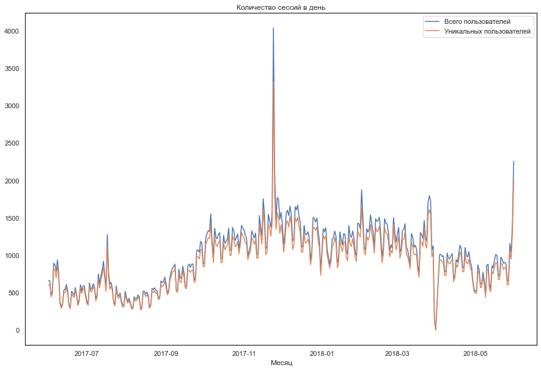

```python
ax = visits.groupby(['session_date']).agg({'uid': ['count','nunique']}).plot(figsize=(15, 10));

ax.set_title("Количество сессий в день");
ax.set_xlabel('Месяц');
ax.legend(['Всего пользователей', 'Уникальных пользователей']);
```